# 3D Registration

```python
import SimpleITK as sitk
import time
import os
import copy
from GetDicomFpaths import GetDicomFpaths
```

### Define the directories of Fixed and Moving:

```python
FixedDir = r'C:\Temp\ACRIN_MR_DICOMs'
MovingDir = r'C:\Temp\ACRIN_CT_DICOMs'
```

### First tried using sitk.JoinSeries(FixedVectorOfImages) and sitk.JoinSeries(MovingVectorOfImages) but not sure JoinSeries is appropriate to use here...

```python
# Use GetDicomFpaths to get list of Fixed and Moving filepaths.
FixedFpaths = GetDicomFpaths(FixedDir, 'slices', Debug=False)
MovingFpaths = GetDicomFpaths(MovingDir, 'slices', Debug=False)


# Start timing:
times = []
times.append(time.time())

# Concatenate the 2D images into one 3D image:
FixedVectorOfImages = sitk.VectorOfImage()
MovingVectorOfImages = sitk.VectorOfImage()

times.append(time.time())
Dtime = round(times[-1] - times[-2], 1)
print(f'\nTook {Dtime} s to concatenate the 2D images.')

for fpath in FixedFpaths:
    FixedVectorOfImages.push_back(sitk.ReadImage(fpath))

times.append(time.time())
Dtime = round(times[-1] - times[-2], 1)
print(f'\nTook {Dtime} s to read the Fixed 3D image stack.')

for fpath in MovingFpaths:
    MovingVectorOfImages.push_back(sitk.ReadImage(fpath))

times.append(time.time())
Dtime = round(times[-1] - times[-2], 1)
print(f'\nTook {Dtime} s to read the Moving 3D image stack.')

FixedIm = sitk.JoinSeries(FixedVectorOfImages)
MovingIm = sitk.JoinSeries(MovingVectorOfImages)

# Register the 3D images:
ImFilter = sitk.ElastixImageFilter()
ImFilter.LogToConsoleOn()
ImFilter.LogToFileOn()
ImFilter.SetFixedImage(FixedIm)
ImFilter.SetMovingImage(MovingIm)
ImFilter.SetParameterMap(sitk.GetDefaultParameterMap('groupwise'))

times.append(time.time())
Dtime = round(times[-1] - times[-2], 1)
print(f'\nTook {Dtime} s to register the 3D image stacks.')
```

```
Took 0.0 s to concatenate the 2D images.

Took 0.6 s to read the Fixed 3D image stack.

Took 0.5 s to read the Moving 3D image stack.
```

```
---------------------------------------------------------------------------
RuntimeError                              Traceback (most recent call last)
<ipython-input-11-15a75ca90ca8> in <module>
     30 print(f'\nTook {Dtime} s to read the Moving 3D image stack.')
     31
---> 32 FixedIm = sitk.JoinSeries(FixedVectorOfImages)
     33 MovingIm = sitk.JoinSeries(MovingVectorOfImages)
     34

~\Anaconda37\lib\site-packages\simpleitk-1.2.0rc2.dev1162+g2a79d-py3.7-win-amd64.egg\SimpleITK\SimpleITK.py in JoinSeries(*args)
  41010     JoinSeries(Image image1, Image image2, Image image3, Image image4, Image image5, double origin=0.0, double spacing=1.0) -> Image
  41011     """
> 41012     return _SimpleITK.JoinSeries(*args)
  41013 class KittlerIllingworthThresholdImageFilter(ImageFilter_0):
  41014     """

RuntimeError: Exception thrown in SimpleITK JoinSeries: C:\SimpleElastix\build_20200108\ITK-prefix\include\ITK-4.13\itkImageToImageFilter.hxx:241:
itk::ERROR: JoinSeriesImageFilter(000001A839C51FC0): Inputs do not occupy the same physical space!
InputImage Origin: [-1.3453753e+02, -1.6707071e+02, -7.9450044e+01], InputImage_1 Origin: [-1.3453753e+02, -1.6707071e+02, -7.8450044e+01]
	Tolerance: 1.0000000e-06
```

### Try registering a stack to itself to see if anything can be made to work:

```python
# Start timing:
times = []
times.append(time.time())

FixedIm = sitk.JoinSeries(FixedVectorOfImages)
#MovingIm = sitk.JoinSeries(MovingVectorOfImages)

# Register the 3D images:
ImFilter = sitk.ElastixImageFilter()
ImFilter.LogToConsoleOn()
ImFilter.LogToFileOn()
ImFilter.SetFixedImage(FixedIm)
#ImFilter.SetMovingImage(MovingIm)
ImFilter.SetMovingImage(FixedIm)
ImFilter.SetParameterMap(sitk.GetDefaultParameterMap('groupwise'))

times.append(time.time())
Dtime = round(times[-1] - times[-2], 1)
print(f'\nTook {Dtime} s to register the 3D image stacks.')
```

```
---------------------------------------------------------------------------
RuntimeError                              Traceback (most recent call last)
<ipython-input-39-4dacc38d0726> in <module>
      3 times.append(time.time())
      4
----> 5 FixedIm = sitk.JoinSeries(FixedVectorOfImages)
      6 #MovingIm = sitk.JoinSeries(MovingVectorOfImages)
      7

~\Anaconda37\lib\site-packages\simpleitk-1.2.0rc2.dev1162+g2a79d-py3.7-win-amd64.egg\SimpleITK\SimpleITK.py in JoinSeries(*args)
  41010     JoinSeries(Image image1, Image image2, Image image3, Image image4, Image image5, double origin=0.0, double spacing=1.0) -> Image
  41011     """
> 41012     return _SimpleITK.JoinSeries(*args)
  41013 class KittlerIllingworthThresholdImageFilter(ImageFilter_0):
  41014     """

RuntimeError: Exception thrown in SimpleITK JoinSeries: C:\SimpleElastix\build_20200108\ITK-prefix\include\ITK-4.13\itkImageToImageFilter.hxx:241:
itk::ERROR: JoinSeriesImageFilter(000001A845E47180): Inputs do not occupy the same physical space!
InputImage Origin: [-1.3453753e+02, -1.6707071e+02, -7.9450044e+01], InputImage_1 Origin: [-1.3453753e+02, -1.6707071e+02, -7.8450044e+01]
	Tolerance: 1.0000000e-06
```

### The error "Inputs do not occupy the same physical space" suggests to me that JoinSeries() is meant to be used to align a series of images of similar physical content - not for a stack of images that correspond to completely different images as is the case in a 3D scan.

### This time use ImageSeriesReader():

```python
FixedReader = sitk.ImageSeriesReader()
FixedNames = FixedReader.GetGDCMSeriesFileNames(FixedDir)
FixedReader.SetFileNames(FixedNames)
FixedIm = FixedReader.Execute()

MovingReader = sitk.ImageSeriesReader()
MovingNames = MovingReader.GetGDCMSeriesFileNames(MovingDir)
MovingReader.SetFileNames(MovingNames)
MovingIm = MovingReader.Execute()

FixedSize = FixedIm.GetSize()
MovingSize = MovingIm.GetSize()
print('\nFixedIm Size  =', FixedSize)
print('MovingIm Size =', MovingSize)

FixedOrigin = FixedIm.GetOrigin()
MovingOrigin = MovingIm.GetOrigin()
print('\nFixedIm Origin  =', FixedOrigin)
print('MovingIm Origin =', MovingOrigin)

FixedSpacing = FixedIm.GetSpacing()
MovingSpacing = MovingIm.GetSpacing()
print('\nFixedIm Spacing  =', FixedSpacing)
print('MovingIm Spacing =', MovingSpacing)


# Start timing:
times = []
times.append(time.time())

# Register the 3D images:
ImFilter = sitk.ElastixImageFilter()
ImFilter.SetFixedImage(FixedIm)
ImFilter.SetMovingImage(MovingIm)
#ImFilter.SetMovingImage(FixedIm)
#ImFilter.SetParameterMap(sitk.GetDefaultParameterMap('groupwise'))
ImFilter.SetParameterMap(sitk.GetDefaultParameterMap('affine'))
ImFilter.LogToConsoleOn()
ImFilter.LogToFileOn()
RegIm3D = ImFilter.Execute()

times.append(time.time())
Dtime = round(times[-1] - times[-2], 1)
print(f'\nTook {Dtime} s to register the 3D image stacks.')
```

```
FixedIm Size  = (256, 256, 160)
MovingIm Size = (512, 512, 72)

FixedIm Origin  = (-134.53753662109375, -167.07070922851562, -79.45004272460938)
MovingIm Origin = (-108.2880859375, -282.97186279296875, 115.51118469238281)

FixedIm Spacing  = (1.0, 1.0, 1.0)
MovingIm Spacing = (0.423828125, 0.423828125, 2.4130020141601562)
```

```
---------------------------------------------------------------------------
RuntimeError                              Traceback (most recent call last)
<ipython-input-14-680fc82b98ab> in <module>
     38 ImFilter.LogToConsoleOn()
     39 ImFilter.LogToFileOn()
---> 40 RegIm3D = ImFilter.Execute()
     41
     42 times.append(time.time())

~\Anaconda37\lib\site-packages\simpleitk-1.2.0rc2.dev1162+g2a79d-py3.7-win-amd64.egg\SimpleITK\SimpleITK.py in Execute(self)
  10994     def Execute(self):
  10995         """Execute(ElastixImageFilter self) -> Image"""
> 10996         return _SimpleITK.ElastixImageFilter_Execute(self)
  10997
  10998

RuntimeError: Exception thrown in SimpleITK ElastixImageFilter_Execute: C:\SimpleElastix\source\SimpleElastix\Code\Elastix\src\sitkElastixImageFilterImpl.cxx:259:
sitk::ERROR:
itk::ExceptionObject (0000007B3E5E79E0)
Location: "unknown"
File: C:\SimpleElastix\build_20200108\Elastix\Core\Main\elxElastixFilter.hxx
Line: 253
Description: itk::ERROR: Self(000001A839B8D510): Internal elastix error: See elastix log (use LogToConsoleOn() or LogToFileOn()).
```

### Try setting some additional distance metrics following the thread:

### https://github.com/SuperElastix/SimpleElastix/issues/70

```python
# Read in the 3D stack of Fixed DICOMs:
FixedReader = sitk.ImageSeriesReader()
FixedNames = FixedReader.GetGDCMSeriesFileNames(FixedDir)
FixedReader.SetFileNames(FixedNames)
FixedIm = FixedReader.Execute()

# Read in the 3D stack of Moving DICOMs:
MovingReader = sitk.ImageSeriesReader()
MovingNames = MovingReader.GetGDCMSeriesFileNames(MovingDir)
MovingReader.SetFileNames(MovingNames)
MovingIm = MovingReader.Execute()

# Start timing:
times = []
times.append(time.time())

# Register the 3D images:
ImFilter = sitk.ElastixImageFilter()
ImFilter.LogToConsoleOn()
ImFilter.LogToFileOn()
"""
Setting some additional parameters following the thread:
https://github.com/SuperElastix/SimpleElastix/issues/70
"""
ImFilter.SetParameter( "Metric", "CorrespondingPointsEuclideanDistanceMetric" )
ImFilter.SetParameter( "Metric", ("NormalizedMutualInformation", "CorrespondingPointsEuclideanDistanceMetric",))
ImFilter.SetParameter("Metric0Weight", "0.0")
ImFilter.SetFixedImage(FixedIm)
ImFilter.SetMovingImage(MovingIm)
ImFilter.SetParameterMap(sitk.GetDefaultParameterMap('affine'))
RegIm = ImFilter.Execute()

times.append(time.time())
Dtime = round(times[-1] - times[-2], 1)
print(f'\nTook {Dtime} s to register the 3D image stacks.')
```

```
---------------------------------------------------------------------------
RuntimeError                              Traceback (most recent call last)
<ipython-input-41-b167822aa80e> in <module>
     29 ImFilter.SetMovingImage(MovingIm)
     30 ImFilter.SetParameterMap(sitk.GetDefaultParameterMap('affine'))
---> 31 RegIm = ImFilter.Execute()
     32
     33 times.append(time.time())

~\Anaconda37\lib\site-packages\simpleitk-1.2.0rc2.dev1162+g2a79d-py3.7-win-amd64.egg\SimpleITK\SimpleITK.py in Execute(self)
  10994     def Execute(self):
  10995         """Execute(ElastixImageFilter self) -> Image"""
> 10996         return _SimpleITK.ElastixImageFilter_Execute(self)
  10997
  10998

RuntimeError: Exception thrown in SimpleITK ElastixImageFilter_Execute: C:\SimpleElastix\source\SimpleElastix\Code\Elastix\src\sitkElastixImageFilterImpl.cxx:259:
sitk::ERROR:
itk::ExceptionObject (0000007B3E5E79E0)
Location: "unknown"
File: C:\SimpleElastix\build_20200108\Elastix\Core\Main\elxElastixFilter.hxx
Line: 253
Description: itk::ERROR: Self(000001A83CC016E0): Internal elastix error: See elastix log (use LogToConsoleOn() or LogToFileOn()).
```

### Same as above but setting the fixed and moving images to be the same:

```python
# Start timing:
times = []
times.append(time.time())

# Register the 3D images:
ImFilter = sitk.ElastixImageFilter()
ImFilter.LogToConsoleOn()
ImFilter.LogToFileOn()
"""
Setting some additional parameters following the thread:
https://github.com/SuperElastix/SimpleElastix/issues/70
"""
ImFilter.SetParameter( "Metric", "CorrespondingPointsEuclideanDistanceMetric" )
ImFilter.SetParameter( "Metric", ("NormalizedMutualInformation", "CorrespondingPointsEuclideanDistanceMetric",))
ImFilter.SetParameter("Metric0Weight", "0.0")
ImFilter.SetFixedImage(FixedIm)
#ImFilter.SetMovingImage(MovingIm)
ImFilter.SetMovingImage(FixedIm) # <-- SetMovingImage = FixedIm
ImFilter.SetParameterMap(sitk.GetDefaultParameterMap('affine'))
RegIm = ImFilter.Execute()

times.append(time.time())
Dtime = round(times[-1] - times[-2], 1)
print(f'\nTook {Dtime} s to register the 3D image stacks.')
```

```
Took 12.5 s to register the 3D image stacks.
```

### So performing a self registration worked.

### Next try setting AutomaticTransformInitializationMethod as in section 5.5.2 in the manual:

```python
# Read in the 3D stack of Fixed DICOMs:
FixedReader = sitk.ImageSeriesReader()
FixedNames = FixedReader.GetGDCMSeriesFileNames(FixedDir)
FixedReader.SetFileNames(FixedNames)
FixedIm = FixedReader.Execute()

# Read in the 3D stack of Moving DICOMs:
MovingReader = sitk.ImageSeriesReader()
MovingNames = MovingReader.GetGDCMSeriesFileNames(MovingDir)
MovingReader.SetFileNames(MovingNames)
MovingIm = MovingReader.Execute()

# Start timing:
times = []
times.append(time.time())

# Register the 3D images:
ImFilter = sitk.ElastixImageFilter()
ImFilter.LogToConsoleOn()
ImFilter.LogToFileOn()
"""
Setting some additional parameters from section 5.5.2 in the manual:
"""
ImFilter.SetParameter( "AutomaticTransformInitializationMethod", "GeometricalCenter" )
ImFilter.SetFixedImage(FixedIm)
ImFilter.SetMovingImage(MovingIm)
ImFilter.SetParameterMap(sitk.GetDefaultParameterMap('affine'))
RegIm = ImFilter.Execute()

times.append(time.time())
Dtime = round(times[-1] - times[-2], 1)
print(f'\nTook {Dtime} s to register the 3D image stacks.')
```

```
---------------------------------------------------------------------------
RuntimeError                              Traceback (most recent call last)
<ipython-input-42-cccd379dce1f> in <module>
     26 ImFilter.SetMovingImage(MovingIm)
     27 ImFilter.SetParameterMap(sitk.GetDefaultParameterMap('affine'))
---> 28 RegIm = ImFilter.Execute()
     29
     30 times.append(time.time())

~\Anaconda37\lib\site-packages\simpleitk-1.2.0rc2.dev1162+g2a79d-py3.7-win-amd64.egg\SimpleITK\SimpleITK.py in Execute(self)
  10994     def Execute(self):
  10995         """Execute(ElastixImageFilter self) -> Image"""
> 10996         return _SimpleITK.ElastixImageFilter_Execute(self)
  10997
  10998

RuntimeError: Exception thrown in SimpleITK ElastixImageFilter_Execute: C:\SimpleElastix\source\SimpleElastix\Code\Elastix\src\sitkElastixImageFilterImpl.cxx:259:
sitk::ERROR:
itk::ExceptionObject (0000007B3E5E79E0)
Location: "unknown"
File: C:\SimpleElastix\build_20200108\Elastix\Core\Main\elxElastixFilter.hxx
Line: 253
Description: itk::ERROR: Self(000001A83CC016E0): Internal elastix error: See elastix log (use LogToConsoleOn() or LogToFileOn()).
```

### Repeat above but perform registration of FixedIm3D to itself:

```python
# Start timing:
times = []
times.append(time.time())

# Register the 3D images:
ImFilter = sitk.ElastixImageFilter()
ImFilter.LogToConsoleOn()
ImFilter.LogToFileOn()
"""
Setting some additional parameters from section 5.5.2 in the manual:
"""
ImFilter.SetParameter( "AutomaticTransformInitializationMethod", "GeometricalCenter" )
ImFilter.SetFixedImage(FixedIm)
#ImFilter.SetMovingImage(MovingIm)
ImFilter.SetMovingImage(FixedIm) # <-- SetMovingImage = FixedIm
ImFilter.SetParameterMap(sitk.GetDefaultParameterMap('affine'))
RegIm = ImFilter.Execute()

times.append(time.time())
Dtime = round(times[-1] - times[-2], 1)
print(f'\nTook {Dtime} s to register the 3D image stacks.')

RegSize = RegIm.GetSize()
print('\nRegIm Size  =', RegSize)

RegOrigin = RegIm.GetOrigin()
print('\nRegIm Origin  =', RegOrigin)

RegSpacing = RegIm.GetSpacing()
print('\nRegIm Spacing  =', RegSpacing)
```

```
Took 13.8 s to register the 3D image stacks.

RegIm Size  = (256, 256, 160)

RegIm Origin  = (-134.53753662109375, -167.07070922851562, -79.45004272460938)

RegIm Spacing  = (1.0, 1.0, 1.0)
```

### So performing a self-registration worked.

### Next try reversing the Fixed and Moving stack as in the following:

### https://groups.google.com/forum/#!category-topic/elastix-imageregistration/simpleelastix/HPVGTR5V6cQ

```python
SwapFixedMoving = False
#SwapFixedMoving = True

if SwapFixedMoving:
    print('FixedDir and MovingDir swapped.')
else:
    print('FixedDir and MovingDir as originally defined.')

# Read in the 3D stack of Fixed DICOMs:
FixedReader = sitk.ImageSeriesReader()
#FixedReader = sitk.ImageSeriesReader(sitk.sitkFloat32)
if SwapFixedMoving:
    FixedNames = FixedReader.GetGDCMSeriesFileNames(MovingDir)
else:
    FixedNames = FixedReader.GetGDCMSeriesFileNames(FixedDir)
FixedReader.SetFileNames(FixedNames)
FixedIm = FixedReader.Execute()
FixedIm = sitk.Cast(FixedIm, sitk.sitkFloat32)

# Read in the 3D stack of Moving DICOMs:
MovingReader = sitk.ImageSeriesReader()
#MovingReader = sitk.ImageSeriesReader(sitk.sitkFloat32)
if SwapFixedMoving:
    MovingNames = MovingReader.GetGDCMSeriesFileNames(FixedDir)
else:
    MovingNames = MovingReader.GetGDCMSeriesFileNames(MovingDir)
MovingReader.SetFileNames(MovingNames)
MovingIm = MovingReader.Execute()
#MovingIm = MovingReader.Execute(sitk.sitkFloat32)
MovingIm = sitk.Cast(MovingIm, sitk.sitkFloat32)

#FixedDtype = str(FixedIm.dtype)
FixedDtype = FixedIm.GetPixelIDTypeAsString()
#MovingDtype = str(MovingIm.dtype)
MovingDtype = MovingIm.GetPixelIDTypeAsString()
print('\nFixedIm Dtype  =', FixedDtype)
print('MovingIm Dtype =', MovingDtype)

FixedSize = FixedIm.GetSize()
MovingSize = MovingIm.GetSize()
print('\nFixedIm Size  =', FixedSize)
print('MovingIm Size =', MovingSize)

FixedSpacing = FixedIm.GetSpacing()
MovingSpacing = MovingIm.GetSpacing()
print('\nFixedIm Spacing  =', FixedSpacing)
print('MovingIm Spacing =', MovingSpacing)

FixedOrigin = FixedIm.GetOrigin()
MovingOrigin = MovingIm.GetOrigin()
print('\nFixedIm Origin  =', FixedOrigin)
print('MovingIm Origin =', MovingOrigin)

# Start timing:
times = []
times.append(time.time())

# Register the 3D images:
ImFilter = sitk.ElastixImageFilter()
ImFilter.LogToConsoleOn()
ImFilter.LogToFileOn()
"""
Setting some additional parameters from section 5.5.2 in the manual:
"""
ImFilter.SetParameter( "AutomaticTransformInitializationMethod", "GeometricalCenter" )
ImFilter.SetFixedImage(FixedIm)
ImFilter.SetMovingImage(MovingIm)
ImFilter.SetParameterMap(sitk.GetDefaultParameterMap('affine'))
RegIm = ImFilter.Execute()

times.append(time.time())
Dtime = round(times[-1] - times[-2], 1)
print(f'\nTook {Dtime} s to register the 3D image stacks.')

RegSize = RegIm.GetSize()
print('\nRegIm Size  =', RegSize)

RegSpacing = RegIm.GetSpacing()
print('\nRegIm Spacing  =', RegSpacing)

RegOrigin = RegIm.GetOrigin()
print('\nRegIm Origin  =', RegOrigin)
```

```
FixedDir and MovingDir as originally defined.

FixedIm Dtype  = 32-bit float
MovingIm Dtype = 32-bit float

FixedIm Size  = (256, 256, 160)
MovingIm Size = (512, 512, 72)

FixedIm Spacing  = (1.0, 1.0, 1.0)
MovingIm Spacing = (0.423828125, 0.423828125, 2.4130020141601562)

FixedIm Origin  = (-134.53753662109375, -167.07070922851562, -79.45004272460938)
MovingIm Origin = (-108.2880859375, -282.97186279296875, 115.51118469238281)
```

```
---------------------------------------------------------------------------
RuntimeError                              Traceback (most recent call last)
<ipython-input-45-9c109baf1f8c> in <module>
     67 ImFilter.SetMovingImage(MovingIm)
     68 ImFilter.SetParameterMap(sitk.GetDefaultParameterMap('affine'))
---> 69 RegIm = ImFilter.Execute()
     70
     71 times.append(time.time())

~\Anaconda37\lib\site-packages\simpleitk-1.2.0rc2.dev1162+g2a79d-py3.7-win-amd64.egg\SimpleITK\SimpleITK.py in Execute(self)
  10994     def Execute(self):
  10995         """Execute(ElastixImageFilter self) -> Image"""
> 10996         return _SimpleITK.ElastixImageFilter_Execute(self)
  10997
  10998

RuntimeError: Exception thrown in SimpleITK ElastixImageFilter_Execute: C:\SimpleElastix\source\SimpleElastix\Code\Elastix\src\sitkElastixImageFilterImpl.cxx:259:
sitk::ERROR:
itk::ExceptionObject (0000007B3E5E79E0)
Location: "unknown"
File: C:\SimpleElastix\build_20200108\Elastix\Core\Main\elxElastixFilter.hxx
Line: 253
Description: itk::ERROR: Self(000001A83CC01540): Internal elastix error: See elastix log (use LogToConsoleOn() or LogToFileOn()).
```

### That didn't help, even after casting to float32.

### April 30:

### Try following the example shown in this tutorial:

### https://github.com/InsightSoftwareConsortium/SimpleITKWorkshopImageJ2015/blob/master/6_Similarity_Metrics_and_Optimization.ipynb

```python
# Define utility functions:

import matplotlib.pyplot as plt
%matplotlib inline

from ipywidgets import interact, fixed
from IPython.display import clear_output

# callback invoked by the interact ipython method for scrolling through the image stacks of
# the two images (moving and fixed)
def display_images(fixed_image_z, moving_image_z, fixed_npa, moving_npa):
    # create a figure with two subplots and the specified size
    plt.subplots(1,2,figsize=(10,8))

    # draw the fixed image in the first subplot
    plt.subplot(1,2,1)
    plt.imshow(fixed_npa[fixed_image_z,:,:],cmap=plt.cm.Greys_r);
    plt.title('fixed image')
    plt.axis('off')

    # draw the moving image in the second subplot
    plt.subplot(1,2,2)
    plt.imshow(moving_npa[moving_image_z,:,:],cmap=plt.cm.Greys_r);
    plt.title('moving image')
    plt.axis('off')

# callback invoked by the ipython interact method for scrolling and modifying the alpha blending
# of an image stack of two images that occupy the same physical space.
def display_images_with_alpha(image_z, alpha, fixed, moving):
    img = (1.0 - alpha)*fixed[:,:,image_z] + alpha*moving[:,:,image_z]
    plt.imshow(sitk.GetArrayFromImage(img),cmap=plt.cm.Greys_r);
    plt.axis('off')


# callback invoked when the StartEvent happens, sets up our new data
def start_plot():
    global metric_values, multires_iterations

    metric_values = []
    multires_iterations = []

# callback invoked when the EndEvent happens, do cleanup of data and figure
def end_plot():
    global metric_values, multires_iterations

    del metric_values
    del multires_iterations
    #close figure, we don't want to get a duplicate of the plot latter on
    plt.close()

# callback invoked when the IterationEvent happens, update our data and display new figure
def plot_values(registration_method):
    global metric_values, multires_iterations

    metric_values.append(registration_method.GetMetricValue())
    #clear the output area (wait=True, to reduce flickering), and plot current data
    clear_output(wait=True)
    #plot the similarity metric values
    plt.plot(metric_values, 'r')
    plt.plot(multires_iterations, [metric_values[index] for index in multires_iterations], 'b*')
    plt.xlabel('Iteration Number',fontsize=12)
    plt.ylabel('Metric Value',fontsize=12)
    plt.show()

# callback invoked when the sitkMultiResolutionIterationEvent happens, update the index into the
# metric_values list.
def update_multires_iterations():
    global metric_values, multires_iterations
    multires_iterations.append(len(metric_values))
```

```python
# Read images:

#fixed_image =  sitk.ReadImage("Data/training_001_ct.mha",
#                              sitk.sitkFloat32)
#moving_image = sitk.ReadImage("Data/training_001_mr_T1.mha",
#                              sitk.sitkFloat32)

# Read in the 3D stack of Fixed DICOMs:
FixedReader = sitk.ImageSeriesReader()
FixedNames = FixedReader.GetGDCMSeriesFileNames(FixedDir)
FixedReader.SetFileNames(FixedNames)
FixedIm = FixedReader.Execute()

# Read in the 3D stack of Moving DICOMs:
MovingReader = sitk.ImageSeriesReader()
MovingNames = MovingReader.GetGDCMSeriesFileNames(MovingDir)
MovingReader.SetFileNames(MovingNames)
MovingIm = MovingReader.Execute()

interact(display_images,
         fixed_image_z=(0,FixedIm.GetSize()[2]-1),
         moving_image_z=(0,MovingIm.GetSize()[2]-1),
         fixed_npa = fixed(sitk.GetArrayFromImage(FixedIm)),
         moving_npa = fixed(sitk.GetArrayFromImage(MovingIm)));
```

```python
# Initial alignment:

CenteringMode = sitk.CenteredTransformInitializerFilter.GEOMETRY

InitialTransform = \
    sitk.CenteredTransformInitializer(FixedIm,
                                      MovingIm,
                                      sitk.Euler3DTransform(),
                                      CenteringMode)

MovingImResampled = sitk.Resample(MovingIm,
                                  FixedIm,
                                  InitialTransform,
                                  sitk.sitkLinear,
                                  0.0,
                                  MovingIm.GetPixelIDValue())

interact(display_images_with_alpha,
         image_z=(0,FixedIm.GetSize()[2]),
         alpha=(0.0,1.0,0.05),
         fixed = fixed(FixedIm),
         moving=fixed(MovingImResampled));
```

```
---------------------------------------------------------------------------
RuntimeError                              Traceback (most recent call last)
<ipython-input-26-7f0147a239e0> in <module>
      7                                       MovingIm,
      8                                       sitk.Euler3DTransform(),
----> 9                                       CenteringMode)
     10
     11 MovingImResampled = sitk.Resample(MovingIm,

~\Anaconda37\lib\site-packages\simpleitk-1.2.0rc2.dev1162+g2a79d-py3.7-win-amd64.egg\SimpleITK\SimpleITK.py in CenteredTransformInitializer(*args, **kwargs)
   9677
   9678     """
-> 9679     return _SimpleITK.CenteredTransformInitializer(*args, **kwargs)
   9680 class CenteredVersorTransformInitializerFilter(ProcessObject):
   9681     """

RuntimeError: Exception thrown in SimpleITK CenteredTransformInitializer: C:\SimpleElastix\source\SimpleElastix\Code\BasicFilters\src\sitkCenteredTransformInitializerFilter.cxx:100:
sitk::ERROR: Moving Image parameter for CenteredTransformInitializerFilter doesn't match type or dimension!
```

### Modify the code a bit based on zivy's suggested resampling code on 25 Sept 2018 under "def GlobalAffineRegistration(fixed,moving)":

### https://github.com/SimpleITK/SimpleITK/issues/576

```python
# Initial alignment:

#CenteringMode = sitk.CenteredTransformInitializerFilter.GEOMETRY

#InitialTransform = \
#    sitk.CenteredTransformInitializer(FixedIm,
#                                      MovingIm,
#                                      sitk.Euler3DTransform(),
#                                      CenteringMode)
#
#MovingImResampled = sitk.Resample(MovingIm,
#                                  FixedIm,
#                                  InitialTransform,
#                                  sitk.sitkLinear,
#                                  0.0,
#                                  MovingIm.GetPixelIDValue())

InitialTransform = \
    sitk.CenteredTransformInitializer(FixedIm,
                                      MovingIm,
                                      sitk.AffineTransform(FixedIm.GetDimension()))


Resampler = sitk.ImageRegistrationMethod()

Resampler.SetMetricAsJointHistogramMutualInformation(32)

Resampler.SetOptimizerAsGradientDescent(learningRate=1.0,
                                        numberOfIterations=100,
                                        estimateLearningRate = Resampler.EachIteration)

Resampler.SetOptimizerScalesFromPhysicalShift()
Resampler.SetInitialTransform(InitialTransform, inPlace=False)
Resampler.SetInterpolator(sitk.sitkLinear)

ResamplerTransform = Resampler.Execute(sitk.Cast(FixedIm, sitk.sitkFloat32),
                                       sitk.Cast(MovingIm, sitk.sitkFloat32))

MovingImResampled = sitk.Resample(MovingIm, FixedIm, ResamplerTransform,
                                  sitk.sitkLinear, 0.0, MovingIm.GetPixelID())

interact(display_images_with_alpha,
         image_z=(0,FixedIm.GetSize()[2]),
         alpha=(0.0,1.0,0.05),
         fixed = fixed(FixedIm),
         moving=fixed(MovingImResampled));
```

### No errors this time but not sure where to go from here. No images displayed..

### May 1: Use as a template the following tutorial:

### https://github.com/SimpleITK/SPIE2018_COURSE/blob/master/04_basic_registration.ipynb

```
FixedDir = C:\Temp\ACRIN_MR_DICOMs
MovingDir = C:\Temp\ACRIN_CT_DICOMs

Original FixedIm Dtype  = 16-bit unsigned integer
Original MovingIm Dtype = 16-bit signed integer

FixedIm3D Dtype after Cast()  = 32-bit float
MovingIm3D Dtype after Cast() = 32-bit float

FixedIm Size  = (256, 256, 160)
MovingIm Size = (512, 512, 72)

FixedIm Spacing  = (1.0, 1.0, 1.0)
MovingIm Spacing = (0.423828125, 0.423828125, 2.4130020141601562)

FixedIm Origin  = (-134.53753662109375, -167.07070922851562, -79.45004272460938)
MovingIm Origin = (-108.2880859375, -282.97186279296875, 115.51118469238281)
```

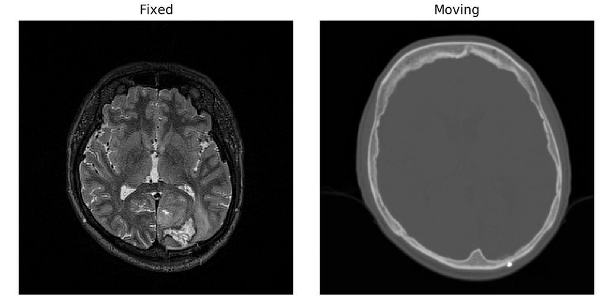

```python
import SimpleITK as sitk
#from downloaddata import fetch_data as fdata
%matplotlib notebook
import gui
import registration_gui as rgui

import numpy as np
import os
import time
import copy
from CreateDir import CreateDir

# Define the directory to export results to:
#TodaysDate = time.strftime("%Y-%m-%d", time.gmtime())
#RootDir = 'C:\Temp'
#ExportDir = os.path.join(r'C:\Temp', TodaysDate)
#CreateDir(ExportDir, Debug=False)

print('FixedDir =', FixedDir)
print('MovingDir =', MovingDir)

# Read in the 3D stack of Fixed DICOMs:
FixedReader = sitk.ImageSeriesReader()
FixedFilenames = FixedReader.GetGDCMSeriesFileNames(FixedDir)
FixedReader.SetFileNames(FixedFilenames)
FixedIm = FixedReader.Execute()

# Read in the 3D stack of Moving DICOMs:
MovingReader = sitk.ImageSeriesReader()
MovingFilenames = MovingReader.GetGDCMSeriesFileNames(MovingDir)
MovingReader.SetFileNames(MovingFilenames)
MovingIm = MovingReader.Execute()

# Print original pixel data type:
FixedDtype = FixedIm.GetPixelIDTypeAsString()
MovingDtype = MovingIm.GetPixelIDTypeAsString()
print('\nOriginal FixedIm Dtype  =', FixedDtype)
print('Original MovingIm Dtype =', MovingDtype)

# Convert from int16/uint16 to float32:
FixedIm = sitk.Cast(FixedIm, sitk.sitkFloat32)
MovingIm = sitk.Cast(MovingIm, sitk.sitkFloat32)

# Print original pixel data type after casting to float32:
FixedDtype = FixedIm.GetPixelIDTypeAsString()
MovingDtype = MovingIm.GetPixelIDTypeAsString()
print('\nFixedIm3D Dtype after Cast()  =', FixedDtype)
print('MovingIm3D Dtype after Cast() =', MovingDtype)

FixedSize = FixedIm.GetSize()
MovingSize = MovingIm.GetSize()
print('\nFixedIm Size  =', FixedSize)
print('MovingIm Size =', MovingSize)

FixedSpacing = FixedIm.GetSpacing()
MovingSpacing = MovingIm.GetSpacing()
print('\nFixedIm Spacing  =', FixedSpacing)
print('MovingIm Spacing =', MovingSpacing)

FixedOrigin = FixedIm.GetOrigin()
MovingOrigin = MovingIm.GetOrigin()
print('\nFixedIm Origin  =', FixedOrigin)
print('MovingIm Origin =', MovingOrigin)

gui.MultiImageDisplay(image_list = [FixedIm, MovingIm],
                      title_list = ['Fixed', 'Moving'], figure_size=(8,4));
```

### Perform "classical" registration:

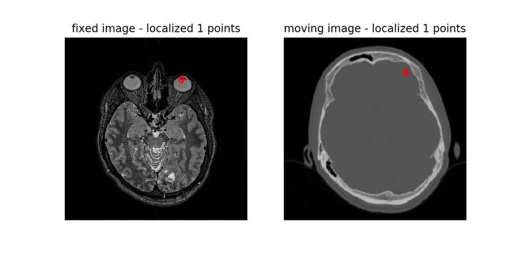

```python
# Initialize registration by aligning the centers of the two volumes.
# To qualitatively evaluate the result we use a linked cursor approach,
# click on one image and the corresponding point is added to the other image.

InitialTransform = sitk.CenteredTransformInitializer(FixedIm,
                                                     MovingIm,
                                                     sitk.Euler3DTransform(),
                                                     sitk.CenteredTransformInitializerFilter.GEOMETRY)

gui.RegistrationPointDataAquisition(FixedIm, MovingIm, figure_size=(8,4),
                                    known_transformation=InitialTransform);
```

### Try again but with reversal of Fixed/Moving:

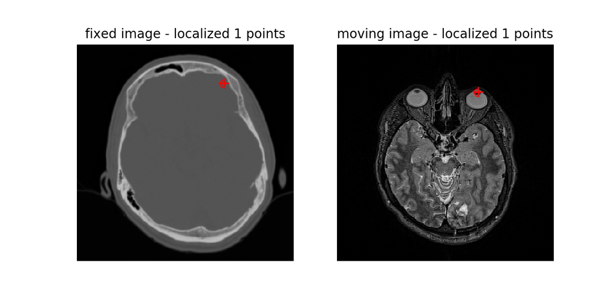

```python
# Initialize registration by aligning the centers of the two volumes.
# To qualitatively evaluate the result we use a linked cursor approach,
# click on one image and the corresponding point is added to the other image.

InitialTransform = sitk.CenteredTransformInitializer(MovingIm,
                                                     FixedIm,
                                                     sitk.Euler3DTransform(),
                                                     sitk.CenteredTransformInitializerFilter.GEOMETRY)

gui.RegistrationPointDataAquisition(MovingIm, FixedIm, figure_size=(8,4),
                                    known_transformation=InitialTransform);
```

### Swapping FixedIm/MovingIm made no difference.

### Next try setting the similarity metric and optimiser settings:

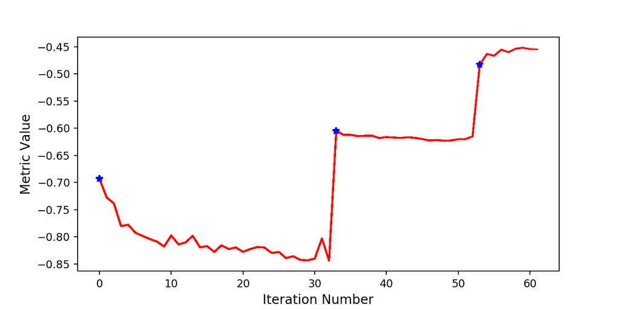

```
Final metric value: -0.45672759561042586
Optimizer's stopping condition: GradientDescentOptimizerv4Template: Convergence checker passed at iteration 9.
```

```python
# First re-define InitialTransform as before swapping Fixed with Moving:
# Initialize registration by aligning the centers of the two volumes.
# To qualitatively evaluate the result we use a linked cursor approach,
# click on one image and the corresponding point is added to the other image.

InitialTransform = sitk.CenteredTransformInitializer(FixedIm,
                                                     MovingIm,
                                                     sitk.Euler3DTransform(),
                                                     sitk.CenteredTransformInitializerFilter.GEOMETRY)

# Set the similarity metric and optimiser settings:
RegMethod = sitk.ImageRegistrationMethod()

# Similarity metric settings:
RegMethod.SetMetricAsMattesMutualInformation(numberOfHistogramBins=50)
RegMethod.SetMetricSamplingStrategy(RegMethod.RANDOM)
RegMethod.SetMetricSamplingPercentage(0.01)

# Set the interpolator:
RegMethod.SetInterpolator(sitk.sitkLinear)

# Optimiser settings:
RegMethod.SetOptimizerAsGradientDescent(learningRate=1.0,
                                        numberOfIterations=100,
                                        convergenceMinimumValue=1e-6,
                                        convergenceWindowSize=10)

RegMethod.SetOptimizerScalesFromPhysicalShift()

# Setup for the multi-resolution framework:
RegMethod.SetShrinkFactorsPerLevel(shrinkFactors = [4,2,1])
RegMethod.SetSmoothingSigmasPerLevel(smoothingSigmas=[2,1,0])
RegMethod.SmoothingSigmasAreSpecifiedInPhysicalUnitsOn()

# Don't optimize in-place, we would possibly like to run this cell multiple times:
RegMethod.SetInitialTransform(InitialTransform, inPlace=False)
""" Note: InitialTransform = sitk.CenteredTransformInitializerFilter.GEOMETRY """

# Connect all of the observers so that we can perform plotting during registration:
RegMethod.AddCommand(sitk.sitkStartEvent, rgui.start_plot)
RegMethod.AddCommand(sitk.sitkEndEvent, rgui.end_plot)
RegMethod.AddCommand(sitk.sitkMultiResolutionIterationEvent, rgui.update_multires_iterations)
RegMethod.AddCommand(sitk.sitkIterationEvent, lambda: rgui.plot_values(RegMethod))

FinalTransformClassical = RegMethod.Execute(FixedIm, MovingIm)

# Check the reason optimisation terminated:
print(f'Final metric value: {RegMethod.GetMetricValue()}')
print(f'Optimizer\'s stopping condition: {RegMethod.GetOptimizerStopConditionDescription()}')
```

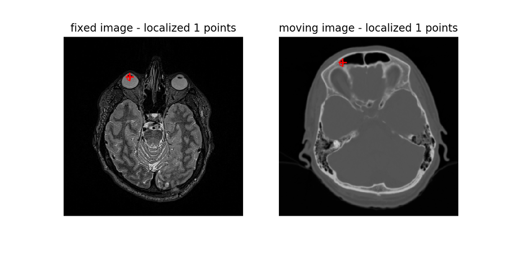

```python
# Qualitatively evaluate the result using a linked cursor approach (visual evaluation):
gui.RegistrationPointDataAquisition(FixedIm, MovingIm, figure_size=(8,4),
                                    known_transformation=FinalTransformClassical);
```

### The points seem to correspond reasonably well, but the moving image doesn't look registered.

### 05/05 Correction: After re-evaluating cells the results now look as poor as the ones above.

```python
# Save the results to file:
#MovingResampled = sitk.Resample(MovingIm, FixedIm, FinalTransform,
#                                sitk.sitkLinear, 0.0, MovingIm.GetPixelID())

#sitk.WriteImage(MovingResampled, os.path.join(ExportDir, 'T2_3D_Slab_resampled.mha'))
#sitk.WriteTransform(FinalTransform, os.path.join(ExportDir, 'T2_3D_Slab_reg_to_HEAD_2-4_H40_SOFT_TISSUE.tfm'))
```

### Use ITK v4 registration framework:

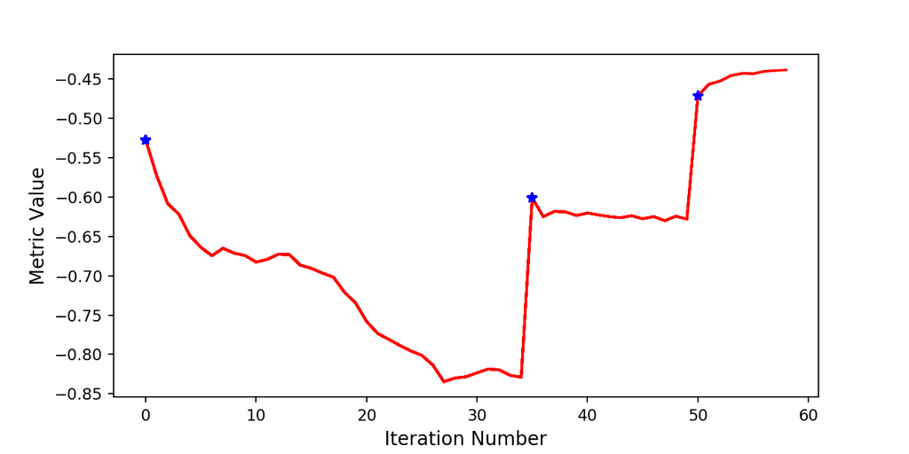

```
Final metric value: -0.4396963245746456
Optimizer's stopping condition: GradientDescentOptimizerv4Template: Convergence checker passed at iteration 9.
```

```python
# Define the registration method:
RegMethod = sitk.ImageRegistrationMethod()

# Similarity metric settings:
RegMethod.SetMetricAsMattesMutualInformation(numberOfHistogramBins=50)
RegMethod.SetMetricSamplingStrategy(RegMethod.RANDOM)
RegMethod.SetMetricSamplingPercentage(0.01)

# Set the interpolator:
RegMethod.SetInterpolator(sitk.sitkLinear)

# Optimizer settings:
RegMethod.SetOptimizerAsGradientDescent(learningRate=1.0,
                                        numberOfIterations=100,
                                        convergenceMinimumValue=1e-6,
                                        convergenceWindowSize=10)

RegMethod.SetOptimizerScalesFromPhysicalShift()

# Setup for the multi-resolution framework:
RegMethod.SetShrinkFactorsPerLevel(shrinkFactors = [4,2,1])
RegMethod.SetSmoothingSigmasPerLevel(smoothingSigmas=[2,1,0])
RegMethod.SmoothingSigmasAreSpecifiedInPhysicalUnitsOn()

""" Note the above is the same as the classical registration.  They depart from here: """

# Set the initial moving and optimised transforms:
OptimizedTransform = sitk.Euler3DTransform()
RegMethod.SetMovingInitialTransform(InitialTransform)
""" Note: InitialTransform = sitk.CenteredTransformInitializerFilter.GEOMETRY """
RegMethod.SetInitialTransform(OptimizedTransform, inPlace=False)

# Connect all of the observers so that we can perform plotting during registration:
RegMethod.AddCommand(sitk.sitkStartEvent, rgui.start_plot)
RegMethod.AddCommand(sitk.sitkEndEvent, rgui.end_plot)
RegMethod.AddCommand(sitk.sitkMultiResolutionIterationEvent, rgui.update_multires_iterations)
RegMethod.AddCommand(sitk.sitkIterationEvent, lambda: rgui.plot_values(RegMethod))

# Need to compose the transformations after registration.
FinalTransform_v4 = RegMethod.Execute(FixedIm, MovingIm)
#FinalTransform_v4.AddTransform(InitialTransform)

# Check the reason optimisation terminated:
print(f'Final metric value: {RegMethod.GetMetricValue()}')
print(f'Optimizer\'s stopping condition: {RegMethod.GetOptimizerStopConditionDescription()}')
```

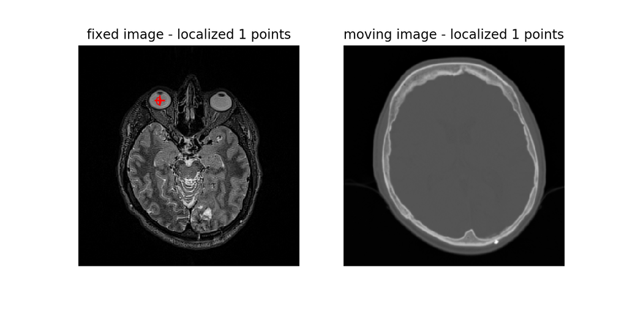

```python
# Qualitatively evaluate the result using a linked cursor approach (visual evaluation):
gui.RegistrationPointDataAquisition(FixedIm, MovingIm, figure_size=(8,4),
                                    known_transformation=FinalTransform_v4);
```

### For some reason the gui doesn't seem to be showing the corresponding moving slice based on the cursor as it had for the classical registration...

### This time try using the identify transform as the initialiser:

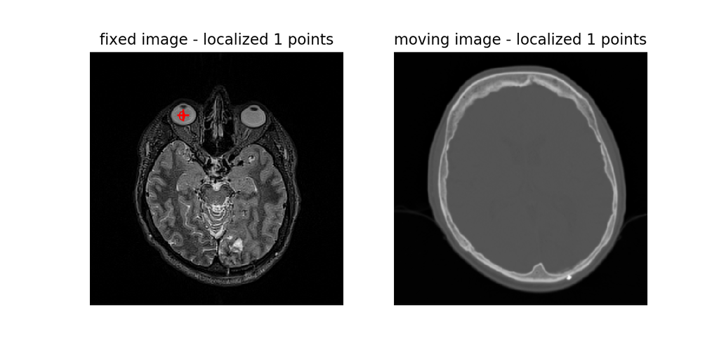

```python
# Use the identity transform as the initial transform:
InitialTransform = sitk.Transform()

gui.RegistrationPointDataAquisition(FixedIm, MovingIm, figure_size=(8,4),
                                    known_transformation=InitialTransform);
```

```python
# Define the registration method:
RegMethod = sitk.ImageRegistrationMethod()

# Similarity metric settings:
RegMethod.SetMetricAsMattesMutualInformation(numberOfHistogramBins=50)
RegMethod.SetMetricSamplingStrategy(RegMethod.RANDOM)
RegMethod.SetMetricSamplingPercentage(0.01)

# Set the interpolator:
RegMethod.SetInterpolator(sitk.sitkLinear)

# Optimizer settings:
RegMethod.SetOptimizerAsGradientDescent(learningRate=1.0,
                                        numberOfIterations=100,
                                        convergenceMinimumValue=1e-6,
                                        convergenceWindowSize=10)

RegMethod.SetOptimizerScalesFromPhysicalShift()

# Setup for the multi-resolution framework:
RegMethod.SetShrinkFactorsPerLevel(shrinkFactors = [4,2,1])
RegMethod.SetSmoothingSigmasPerLevel(smoothingSigmas=[2,1,0])
RegMethod.SmoothingSigmasAreSpecifiedInPhysicalUnitsOn()

""" Note the above is the same as the classical registration.  They depart from here: """

# Set the initial moving and optimised transforms:
OptimizedTransform = sitk.Euler3DTransform()
RegMethod.SetMovingInitialTransform(InitialTransform)
""" Note: InitialTransform = sitk.Transform() i.e. identity transform """
RegMethod.SetInitialTransform(OptimizedTransform, inPlace=False)

# Connect all of the observers so that we can perform plotting during registration:
RegMethod.AddCommand(sitk.sitkStartEvent, rgui.start_plot)
RegMethod.AddCommand(sitk.sitkEndEvent, rgui.end_plot)
RegMethod.AddCommand(sitk.sitkMultiResolutionIterationEvent, rgui.update_multires_iterations)
RegMethod.AddCommand(sitk.sitkIterationEvent, lambda: rgui.plot_values(RegMethod))

# Need to compose the transformations after registration.
FinalTransform_v4 = RegMethod.Execute(FixedIm, MovingIm)
#FinalTransform_v4.AddTransform(InitialTransform)

# Check the reason optimisation terminated:
print(f'Final metric value: {RegMethod.GetMetricValue()}')
print(f'Optimizer\'s stopping condition: {RegMethod.GetOptimizerStopConditionDescription()}')
```

```
---------------------------------------------------------------------------
RuntimeError                              Traceback (most recent call last)
<ipython-input-53-88f42c3731ed> in <module>
     38
     39 # Need to compose the transformations after registration.
---> 40 FinalTransform_v4 = RegMethod.Execute(FixedIm, MovingIm)
     41 #FinalTransform_v4.AddTransform(InitialTransform)
     42

~\Anaconda37\lib\site-packages\simpleitk-1.2.0rc2.dev1162+g2a79d-py3.7-win-amd64.egg\SimpleITK\SimpleITK.py in Execute(self, fixed, moving)
  12131
  12132         """
> 12133         return _SimpleITK.ImageRegistrationMethod_Execute(self, fixed, moving)
  12134
  12135

RuntimeError: Exception thrown in SimpleITK ImageRegistrationMethod_Execute: C:\SimpleElastix\build_20200108\ITK-prefix\include\ITK-4.13\itkMattesMutualInformationImageToImageMetricv4.hxx:205:
itk::ERROR: MattesMutualInformationImageToImageMetricv4(000001A843334170): Joint PDF summed to zero
```

```python
# Get the patient positions:
img = sitk.ReadImage(FixedFilenames[0])
print('Fixed Patient position:  ' + img.GetMetaData('0018|5100'))
img = sitk.ReadImage(MovingFilenames[0])
print('Moving Patient position: ' + img.GetMetaData('0018|5100'))
```

```
Fixed Patient position:  HFS
Moving Patient position: HFS
```

### Try using CenteredTransformInitializer initialization:

Compare GEOMETRY and MOMENTS based approaches.

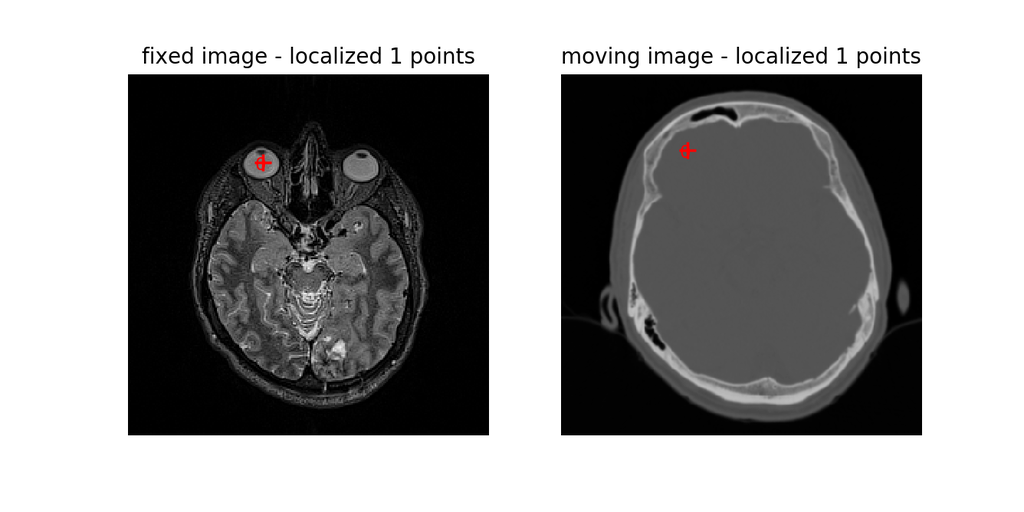

```python
# First GEOMETRY approach:
InitialTransform = sitk.CenteredTransformInitializer(FixedIm,
                                                     MovingIm,
                                                     sitk.Euler3DTransform(),
                                                     sitk.CenteredTransformInitializerFilter.GEOMETRY)

gui.RegistrationPointDataAquisition(FixedIm, MovingIm, figure_size=(8,4),
                                    known_transformation=InitialTransform);
```

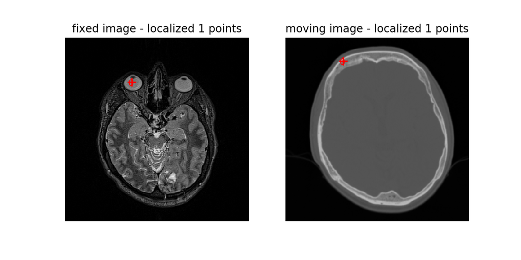

```python
# Next MOMENTS approach:
InitialTransform = sitk.CenteredTransformInitializer(FixedIm,
                                                     MovingIm,
                                                     sitk.Euler3DTransform(),
                                                     sitk.CenteredTransformInitializerFilter.MOMENTS)

gui.RegistrationPointDataAquisition(FixedIm, MovingIm, figure_size=(8,4),
                                    known_transformation=InitialTransform);
```

### Both look highly inaccurate to me!

### Try using the Exhaustive optimizer initialization using CenteredTransformInitializer with GEOMETRY approach:

Compare GEOMETRY and MOMENTS approaches.

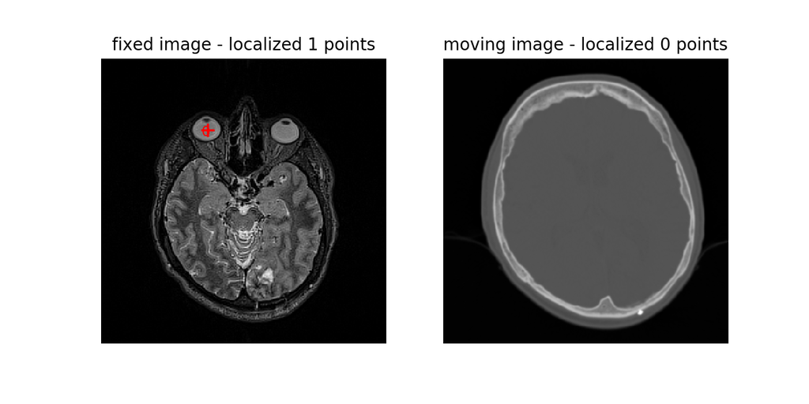

```python
InitialTransform = sitk.CenteredTransformInitializer(FixedIm,
                                                     MovingIm,
                                                     sitk.Euler3DTransform(),
                                                     sitk.CenteredTransformInitializerFilter.GEOMETRY)
RegMethod = sitk.ImageRegistrationMethod()
RegMethod.SetMetricAsMattesMutualInformation(numberOfHistogramBins=50)
RegMethod.SetMetricSamplingStrategy(RegMethod.RANDOM)
RegMethod.SetMetricSamplingPercentage(0.01)
RegMethod.SetInterpolator(sitk.sitkLinear)

# The order of parameters for the Euler3DTransform is [angle_x, angle_y, angle_z, t_x, t_y, t_z]. The parameter
# sampling grid is centered on the InitialTransform parameter values, that are all zero for the rotations. Given
# the number of steps, their length and optimizer scales we have:
# angle_x = 0
# angle_y = -pi, 0, pi
# angle_z = -pi, 0, pi
RegMethod.SetOptimizerAsExhaustive(numberOfSteps=[0,1,1,0,0,0], stepLength = np.pi)
RegMethod.SetOptimizerScales([1,1,1,1,1,1])

# Perform the registration in-place so that the InitialTransform is modified.
RegMethod.SetInitialTransform(InitialTransform, inPlace=True)
""" Note: InitialTransform = sitk.CenteredTransformInitializerFilter.GEOMETRY """
RegMethod.Execute(FixedIm, MovingIm)

gui.RegistrationPointDataAquisition(FixedIm, MovingIm, figure_size=(8,4));
```

### Try MOMENTS this time:

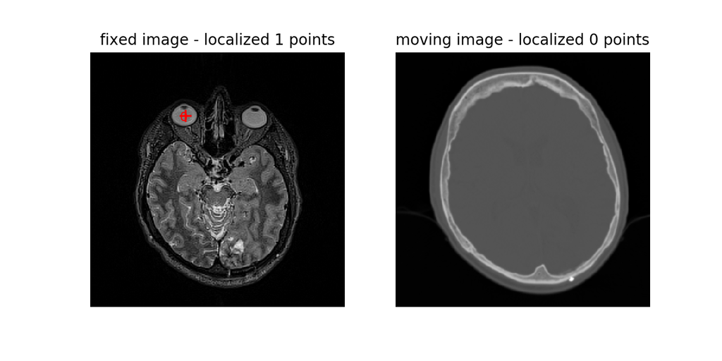

```python
InitialTransform = sitk.CenteredTransformInitializer(FixedIm,
                                                     MovingIm,
                                                     sitk.Euler3DTransform(),
                                                     sitk.CenteredTransformInitializerFilter.MOMENTS)
RegMethod = sitk.ImageRegistrationMethod()
RegMethod.SetMetricAsMattesMutualInformation(numberOfHistogramBins=50)
RegMethod.SetMetricSamplingStrategy(RegMethod.RANDOM)
RegMethod.SetMetricSamplingPercentage(0.01)
RegMethod.SetInterpolator(sitk.sitkLinear)

# The order of parameters for the Euler3DTransform is [angle_x, angle_y, angle_z, t_x, t_y, t_z]. The parameter
# sampling grid is centered on the InitialTransform parameter values, that are all zero for the rotations. Given
# the number of steps, their length and optimizer scales we have:
# angle_x = 0
# angle_y = -pi, 0, pi
# angle_z = -pi, 0, pi
RegMethod.SetOptimizerAsExhaustive(numberOfSteps=[0,1,1,0,0,0], stepLength = np.pi)
RegMethod.SetOptimizerScales([1,1,1,1,1,1])

# Perform the registration in-place so that the InitialTransform is modified.
RegMethod.SetInitialTransform(InitialTransform, inPlace=True)
""" Note: InitialTransform = sitk.CenteredTransformInitializerFilter.MOMENTS """
RegMethod.Execute(FixedIm, MovingIm)

gui.RegistrationPointDataAquisition(FixedIm, MovingIm, figure_size=(8,4));
```

### For some reason the interactive cursor feature is not working, so difficult to assess whether the results of the exhaustive optimiser are any better.

### This is the end of the example covering rigid transformations.